# Using Bioconductor with High Throughput Assays

Bioconductor includes packages for analysis of diverse areas of high-throughput assays such as flow cytometry, quantitative real-time PCR, mass spectrometry, proteomics and other cell-based data.

# 1 Sample Workflow

The following psuedo-code illustrates a typical R / Bioconductor session. It makes use of the flow cytometry packages to load, transform and visualize the flow data and gate certain populations in the dataset.

The workflow loads the `flowCore`, `flowStats` and `flowViz` packages and its dependencies. It loads the ITN data with 15 samples, each of which includes, in addition to FSC and SSC, 5 fluorescence channels: CD3, CD4, CD8, CD69 and HLADR.

```r
## Load packages
library(flowCore)
library(flowStats)
library(flowViz) # for flow data visualization

## Load data
data(ITN)
ITN
```

```
## A flowSet with 15 experiments.
##
## An object of class 'AnnotatedDataFrame'
##   rowNames: sample01 sample02 ... sample15 (15 total)
##   varLabels: GroupID SiteCode ... name (7 total)
##   varMetadata: labelDescription
##
##   column names:
##   FSC SSC CD8 CD69 CD4 CD3 HLADr Time
```

First, we need to transform all the fluorescence channels. Using a `workFlow` object can help to keep track of our progress.

```r
## Create a workflow instance and transform data using asinh
wf <- workFlow(ITN)
asinh <- arcsinhTransform()
tl <- transformList(colnames(ITN)[3:7], asinh,
                      transformationId = "asinh")
add(wf, tl)
```

Next we use the `lymphGate` function to find the T-cells in the CD3/SSC projection.

```
## Note: method with signature 'filter#missing' chosen for function 'glpolygon',
##  target signature 'logicalFilterResult#missing'.
##  "filterResult#ANY" would also be valid
```

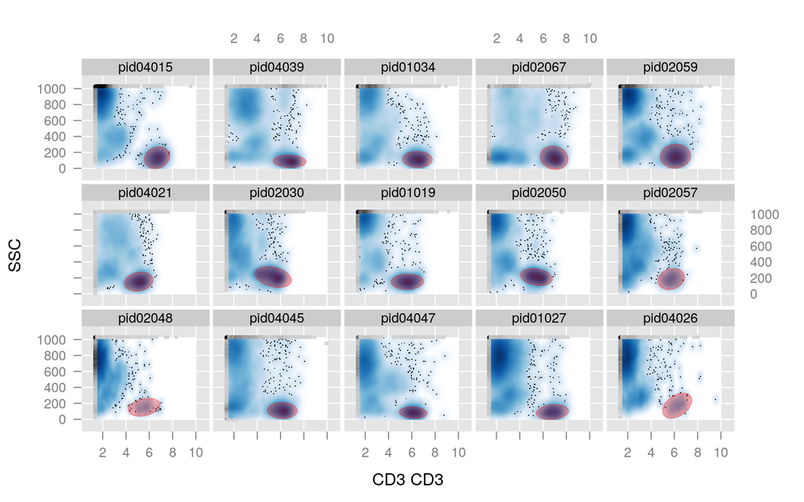

```r
## Identify T-cells population
lg <- lymphGate(Data(wf[["asinh"]]), channels=c("SSC", "CD3"),
         preselection="CD4", filterId="TCells", eval=FALSE,
         scale=2.5)
add(wf, lg$n2gate, parent="asinh")
print(xyplot(SSC ~ CD3| PatientID, wf[["TCells+"]],
             par.settings=list(gate=list(col="red",
             fill="red", alpha=0.3))))
```

A typical workflow for flow cytometry data analysis in Bioconductor flow packages include data transformation, normalization, filtering, manual gating, semi-automatic gating and automatic clustering if desired. Details can be found in flowWorkFlow.pdf or the vignettes of the flow cytometry packages.

# 2 Installation and Use

Follow installation instructions to start using these packages. To install the `flowCore` package and all of its dependencies, evaluate the commands

```r
## try http:// if https:// URLs are not supported
source("https://bioconductor.org/biocLite.R")
biocLite("flowCore")
```

Package installation is required only once per R installation. View a full list of available packages.

To use the `flowCore` package, evaluate the command

```r
library("flowCore")
```

This instruction is required once in each R session.

# 3 Exploring Package Content

Packages have extensive help pages, and include vignettes highlighting common use cases. The help pages and vignettes are available from within R. After loading a package, use syntax like

```
help(package="flowCore")
?read.FCS
```

to obtain an overview of help on the `flowCore` package, and the `read.FCS` function, and

```r
browseVignettes(package="flowCore")
```

to view vignettes (providing a more comprehensive introduction to package functionality) in the `flowCore` package. Use

```r
help.start()
```

to open a web page containing comprehensive help resources.

# 4 Diverse Assays Resources

The following provide a brief overview of packages useful for analysis of high-throughput assays. More comprehensive workflows can be found in documentation (available from package descriptions) and in Bioconductor publications.

## 4.1 Flow Cytometry

These packages use standard FCS files, including infrastructure, utilities, visualization and semi-autogating methods for the analysis of flow cytometry data.

flowCore, flowViz, flowQ, flowStats, flowUtils, flowFP, flowTrans,

Algorithms for clustering flow cytometry data are found in these packages:

flowClust, flowMeans, flowMerge, SamSPECTRAL

A typical workflow using the packages `flowCore`, `flowViz`, `flowQ` and `flowStats` is described in detail in flowWorkFlow.pdf. The data files used in the workflow can be downloaded from here.

## 4.2 Cell-based Assays

These packages provide data structures and algorithms for cell-based high-throughput screens (HTS).

cellHTS2, RNAither

This package supports the xCELLigence system which contains a series of real-time cell analyzer (RTCA).

RTCA

## 4.3 High-throughput qPCR Assays

These package provide algorithm for the analysis of cycle threshold (Ct) from quantitative real-time PCR data.

HTqPCR, ddCt, qpcrNorm

## 4.4 Mass Spectrometry and Proteomics data

These packages provide framework for processing, visualization, and statistical analysis of mass spectral and proteomics data.

clippda, MassArray, MassSpecWavelet, PROcess, flagme, xcms

## 4.5 Imaging Based Assays

These packages provide infrastructure for image-based phenotyping and automation of other image-related tasks:

EBImage, imageHTS